# Taxi - Tip Prediction Project

2017-10-29

# 1 Data Understanding and Data Preparation

The first part of the analysis is devided by IDA and EDA. Those are the preliminary steps before feature engineering, modeling and the final evaluation stage.

# 2 Initial Data Analysis

Here are some of the ideas and questions that are behind IDA and EDA for the Taxi data set:

**IDA (Initial Data Analysis)**

- are there any external data sets that we can use in combination with our main data set?
- are there any *NA’s* in the data set?
- are the data tpyes correctly assigned?
- are there any errors/anomalies within the data set?
- create features that could be very informitative during EDA and predictiong modeling stage.

**EDA (Exploratory Data Analysis)**

- the find out the distribution of the data set
- what are the relationships between the features and how does each feature relate with target feature?
- are there any outliners and the explanation behind those outliners

## 2.1 Load Libraries and Helper Functions

```r
library("Hmisc") # Descriptive Statistics
library("psych") # Descriptive Statistics
library('tidyverse') # ggplot2, dplyr, tidyr, readr, purrr, tibble
# library('scales') # visualisation
library('grid') # visualisation
library('RColorBrewer') # visualisation
library('corrplot') # visualisation
library('alluvial') # visualisation
library('plotly')
library('readr') # input/output
library('data.table') # data manipulation
library('tidyr') # data wrangling
library('stringr') # string manipulation
library('forcats') # factor manipulation
library('lubridate') # date and time
library('xgboost') # modelling
library('caret') # modelling
library("DT") # creating tables
library("knitr") # rmarkdown
```

The multiplot function is used for gathering several graphs into more appealing format. Down below is the explanation how to use it. To learn more visit the Cookbook for R.

```r
# Define multiple plot function
#
# ggplot objects can be passed in ..., or to plotlist (as a list of ggplot objects)
# - cols:   Number of columns in layout
# - layout: A matrix specifying the layout. If present, 'cols' is ignored.
#
# If the layout is something like matrix(c(1,2,3,3), nrow=2, byrow=TRUE),
# then plot 1 will go in the upper left, 2 will go in the upper right, and
# 3 will go all the way across the bottom.
#
multiplot <- function(..., plotlist=NULL, file, cols=1, layout=NULL) {

  # Make a list from the ... arguments and plotlist
  plots <- c(list(...), plotlist)

  numPlots = length(plots)

  # If layout is NULL, then use 'cols' to determine layout
  if (is.null(layout)) {
    # Make the panel
    # ncol: Number of columns of plots
    # nrow: Number of rows needed, calculated from # of cols
    layout <- matrix(seq(1, cols * ceiling(numPlots/cols)),
                    ncol = cols, nrow = ceiling(numPlots/cols))
  }

 if (numPlots==1) {
    print(plots[[1]])

  } else {
    # Set up the page
    grid.newpage()
    pushViewport(viewport(layout = grid.layout(nrow(layout), ncol(layout))))

    # Make each plot, in the correct location
    for (i in 1:numPlots) {
      # Get the i,j matrix positions of the regions that contain this subplot
      matchidx <- as.data.frame(which(layout == i, arr.ind = TRUE))

      print(plots[[i]], vp = viewport(layout.pos.row = matchidx$row,
                                      layout.pos.col = matchidx$col))
    }
  }
}


# Normalize Function
normalize <- function(x) {
    return ((x - min(x)) / (max(x) - min(x)))
}
```

## 2.2 Load The Data Sets

The first data set is the Taxi data set and is the basis upon which we will try to predict the tip amount, based on other features.

### 2.2.1 Loading Taxi Main Data Set

```r
taxi_data <- "sample100000.csv"
taxi_data <- as.tibble(fread(taxi_data))

taxi_data <- taxi_data %>%
  mutate(date = date(pickup_datetime),
         wday = wday(pickup_datetime, label = TRUE),
         wday = fct_relevel(wday, c("Mon", "Tues", "Wed", "Thurs", "Fri", "Sat", "Sun")),
         hour = hour(pickup_datetime),
         work = (hour %in% seq(8,18)) & (wday %in% c("Mon","Tues","Wed","Thurs","Fri")),
         trip_duration = round(digits = 4, difftime(dropoff_datetime, pickup_datetime))) %>%
  arrange(pickup_datetime)
```

Here are some of the features that we have created from pre-existing features in the taxi_data:

- date: date was created because it will serve as a primary key between taxi_data and weather data set.
- wday: is devided upon **7** days of the week.
- hour: indicates a hour of a day for each observation
- work: if TRUE then that means the observation was recorded during the work time, while FALSE records the observation after the working hours
- trip_duration: represents the difference between dropoff and pickup time.

### 2.2.2 Loading The Weather Data Set

The Weather data set was taken from the [NCDC](https://www.ncdc.noaa.gov/)

```r
weather <- "weather.csv"
weather <- as.tibble(fread(weather))

weather <- weather %>%
  select(DATE, TMAX,TMIN)

weather <- weather %>%
  mutate(date = date(DATE))

foo <- weather %>%
  select(date,TMAX, TMIN)

#rm(weather)

foo <- foo %>%
 filter(date > "2015-05-31" & date <"2015-07-1")

foo <- foo %>%
  head(30)
```

Weather data set represents date, maximal and minimal temperature for each day of the month for June. Date feature is a key feature, with which we will connect the taxi_data and weather data sets.

### 2.2.3 Combining The Two Data Sets

```r
complete_dataset <- taxi_data %>%
  inner_join(foo, by = "date")
#rm(foo)
#rm(taxi_data)
```

## 2.3 Data Set

```r
complete_dataset %>%
  head(25) %>%
  DT::datatable(options = list(pageLength=10, scrollX='400px'), filter = 'top')
```

|  | pickup_datetime | pickup_borough | pickup_neighborhood | dropoff_datetime | dropoff_borough | dropoff_neighborhood | passenger_count | trip_distance | payment_type | fare_amount | extra | tip_amount | tolls_amount | date | wday | hour | work | trip_duration | TMAX | TMIN |
| --- | --- | --- | --- | --- | --- | --- | --- | --- | --- | --- | --- | --- | --- | --- | --- | --- | --- | --- | --- | --- |
| 1 | 2015-06-01 00:02:01 | Queens | West Queens | 2015-06-01 00:23:35 | Manhattan | Lower East Side | 1 | 9.2 | 1 | 27 | 0.5 | 6.75 | 5.54 | 2015-06-01 | Mon | 0 | False | 21.5667 | 87 | 55 |
| 2 | 2015-06-01 00:02:58 | Manhattan | Greenwich Village and Soho | 2015-06-01 00:07:57 | Manhattan | Lower Manhattan | 1 | 1.3 | 2 | 6 | 0.5 | 0 | 0 | 2015-06-01 | Mon | 0 | False | 4.9833 | 87 | 55 |
| 3 | 2015-06-01 00:03:42 | Manhattan | Upper West Side | 2015-06-01 00:14:47 | Manhattan | Central Harlem | 2 | 2.1 | 2 | 10 | 0.5 | 0 | 0 | 2015-06-01 | Mon | 0 | False | 11.0833 | 87 | 55 |
| 4 | 2015-06-01 00:04:24 | Manhattan | Greenwich Village and Soho | 2015-06-01 00:30:53 | Brooklyn | Central Brooklyn | 1 | 7.55 | 1 | 24.5 | 0.5 | 6.45 | 0 | 2015-06-01 | Mon | 0 | False | 26.4833 | 87 | 55 |
| 5 | 2015-06-01 00:04:42 | Manhattan | Lower East Side | 2015-06-01 00:27:34 | Manhattan | Inwood and Washington Heights | 5 | 10.75 | 2 | 31.5 | 0.5 | 0 | 0 | 2015-06-01 | Mon | 0 | False | 22.8667 | 87 | 55 |
| 6 | 2015-06-01 00:04:56 | Queens | Northwest Queens | 2015-06-01 00:10:52 | Queens | Northwest Queens | 1 | 1.7 | 2 | 7.5 | 0.5 | 0 | 0 | 2015-06-01 | Mon | 0 | False | 5.9333 | 87 | 55 |
| 7 | 2015-06-01 00:05:41 | Manhattan | Upper West Side | 2015-06-01 00:14:34 | Manhattan | Upper East Side | 1 | 1.9 | 1 | 8.5 | 0.5 | 1 | 0 | 2015-06-01 | Mon | 0 | False | 8.8833 | 87 | 55 |
| 8 | 2015-06-01 00:06:23 | Manhattan | Chelsea and Clinton | 2015-06-01 00:13:55 | Manhattan | Chelsea and Clinton | 1 | 1.9 | 1 | 8 | 0.5 | 2.3 | 0 | 2015-06-01 | Mon | 0 | False | 7.5333 | 87 | 55 |
| 9 | 2015-06-01 00:07:34 | Manhattan | Lower East Side | 2015-06-01 00:25:47 | Queens | Northwest Queens | 1 | 6.2 | 1 | 20 | 0.5 | 4.25 | 0 | 2015-06-01 | Mon | 0 | False | 18.2167 | 87 | 55 |
| 10 | 2015-06-01 00:07:49 | Queens | West Queens | 2015-06-01 00:26:29 | Manhattan | Chelsea and Clinton | 5 | 9.02 | 1 | 26.5 | 0.5 | 0 | 5.54 | 2015-06-01 | Mon | 0 | False | 18.6667 | 87 | 55 |

[output cut: 15 more lines]

## 2.4 NA check

Great, there aren’t any NA’s in the data set. That most certainly makes the analysis easier, however we have to further investigate if NA’s are registered under some other value.

```r
any(is.na(complete_dataset)) #or
```

```
## [1] FALSE
```

```r
sum(is.na(complete_dataset))
```

```
## [1] 0
```

## 2.5 Data Types Check

```r
glimpse(complete_dataset)
```

```
## Observations: 100,000
## Variables: 20
## $ pickup_datetime      <chr> "2015-06-01 00:02:01", "2015-06-01 00:02:...
## $ pickup_borough       <chr> "Queens", "Manhattan", "Manhattan", "Manh...
## $ pickup_neighborhood  <chr> "West Queens", "Greenwich Village and Soh...
## $ dropoff_datetime     <chr> "2015-06-01 00:23:35", "2015-06-01 00:07:...
## $ dropoff_borough      <chr> "Manhattan", "Manhattan", "Manhattan", "B...
## $ dropoff_neighborhood <chr> "Lower East Side", "Lower Manhattan", "Ce...
## $ passenger_count      <int> 1, 1, 2, 1, 5, 1, 1, 1, 1, 5, 4, 1, 1, 5,...
## $ trip_distance        <dbl> 9.20, 1.30, 2.10, 7.55, 10.75, 1.70, 1.90...
## $ payment_type         <int> 1, 2, 2, 1, 2, 2, 1, 1, 1, 1, 1, 1, 2, 1,...
## $ fare_amount          <dbl> 27.0, 6.0, 10.0, 24.5, 31.5, 7.5, 8.5, 8....
## $ extra                <dbl> 0.5, 0.5, 0.5, 0.5, 0.5, 0.5, 0.5, 0.5, 0...
## $ tip_amount           <dbl> 6.75, 0.00, 0.00, 6.45, 0.00, 0.00, 1.00,...
## $ tolls_amount         <dbl> 5.54, 0.00, 0.00, 0.00, 0.00, 0.00, 0.00,...
## $ date                 <date> 2015-06-01, 2015-06-01, 2015-06-01, 2015...
## $ wday                 <ord> Mon, Mon, Mon, Mon, Mon, Mon, Mon, Mon, M...
## $ hour                 <int> 0, 0, 0, 0, 0, 0, 0, 0, 0, 0, 0, 0, 0, 0,...
## $ work                 <lgl> FALSE, FALSE, FALSE, FALSE, FALSE, FALSE,...
## $ trip_duration        <time> 21.5667 mins, 4.9833 mins, 11.0833 mins,...
## $ TMAX                 <chr> "87", "87", "87", "87", "87", "87", "87",...
## $ TMIN                 <chr> "55", "55", "55", "55", "55", "55", "55",...
```

We see that certain features need to be adjusted into the right data type form.

## 2.6 Changing Data Types Accordingly

The data types are changed because when preforming EDA, ggplo2 and many other packages, it is recommended to have features in certain data type. For example when you want to represent a categorical variable, then it is advised to use factor data type, instead of character data type. Since that shall give an analyst an opportunity to preform greater variety of visualization abilities.

```r
complete_dataset <- complete_dataset %>%
  mutate(pickup_datetime = ymd_hms(pickup_datetime),
         dropoff_datetime = ymd_hms(dropoff_datetime),
         passenger_count = factor(passenger_count),
         pickup_borough = factor(pickup_borough),
         dropoff_borough = factor(dropoff_borough),
         pickup_neighborhood = factor(pickup_neighborhood),
         dropoff_neighborhood = factor(dropoff_neighborhood),
         payment_type = factor(payment_type),
         extra = factor(extra),
         wday = factor(wday),
         work = factor(work),
         trip_duration = as.double(trip_duration),
         TMAX = as.integer(TMAX),
         TMIN = as.integer(TMIN)) %>%
  select(-date)
```

## 2.7 Error Identification Hunt

Next step is to find out are there any errors within the data set. Those errors could occure by importing the data set, data enrty or any other possibility. It is wise to do this check up before doing the data split, because those errors might not occure due to natural occurance, but rather from human or machine error.

## 2.8 View Data By Proportions

```r
# the package won't work with certain time data types, that's why we have to remove them, but not permanmently. It is just for the sake of descriptive statistics

descriptive_stat <- complete_dataset %>%
  select(-c(pickup_datetime, dropoff_datetime))


Hmisc::describe(descriptive_stat) # :: selects particualr function from a library
```

```
## descriptive_stat
##
##  17  Variables      100000  Observations
## ---------------------------------------------------------------------------
## pickup_borough
##        n  missing distinct
##    1e+05    0e+00    4e+00
##
## Value          Bronx  Brooklyn Manhattan    Queens
## Frequency         62      1670     94510      3758
## Proportion     0.001     0.017     0.945     0.038
## ---------------------------------------------------------------------------
## pickup_neighborhood
##        n  missing distinct
##   100000        0       35
##
## lowest : Borough Park              Bronx Park and Fordham    Bushwick and Williamsburg Canarsie and Flatlands    Central Bronx
## highest: Sunset Park               Upper East Side           Upper West Side           West Central Queens       West Queens
## ---------------------------------------------------------------------------
## dropoff_borough
##        n  missing distinct
##    1e+05    0e+00    5e+00
##
## Value              Bronx      Brooklyn     Manhattan        Queens
## Frequency            550          4467         91103          3871
## Proportion         0.006         0.045         0.911         0.039
##
## Value      Staten Island
## Frequency              9
## Proportion         0.000
## ---------------------------------------------------------------------------
## dropoff_neighborhood
##        n  missing distinct
##   100000        0       41
##
## lowest : Borough Park              Bronx Park and Fordham    Bushwick and Williamsburg Canarsie and Flatlands    Central Bronx
## highest: Sunset Park               Upper East Side           Upper West Side           West Central Queens       West Queens
## ---------------------------------------------------------------------------
## passenger_count
##        n  missing distinct
```

[output cut: 102 more lines]

```
## ---------------------------------------------------------------------------
## TMIN
##        n  missing distinct     Info     Mean      Gmd      .05      .10
##    1e+05        0       16    0.991     59.8    7.066       49       49
##      .25      .50      .75      .90      .95
##       55       61       64       68       68
##
## Value         46    49    53    54    55    56    58    59    60    61
## Frequency   3077 10028  3597  3728  6886  6159  3392  5907  6352  3473
## Proportion 0.031 0.100 0.036 0.037 0.069 0.062 0.034 0.059 0.064 0.035
##
## Value         63    64    66    67    68    69
## Frequency   9988 17585  3260  6328  6710  3530
## Proportion 0.100 0.176 0.033 0.063 0.067 0.035
## ---------------------------------------------------------------------------
```

## 2.9 Data Cleaning

After going quickly going through the data proportions there are few potential errors and anomalies. The next step would be to further investigate to see if they are errors made during the data entry, importing or any other stage. This step is similar with the outliner analysis in many ways. The main difference is that in data cleaning stage you are remove anomalies, rather than outliners. Those anomalies do not represent the data set, nor the data set upon which the final model shall be build. Besides imputing or removing the errors, we will also group classes of some categorical features with one another. We do this so that we have less classes with only few observations and secondly when we wanto to create dummy variables out of our categorical features, we will have less features that don’t have any variation in them self, due to the sheer small size of observations.

- passenger_count: It appears that there are occasions where a taxi driver had 0 passengers, but still managed to bill the immaginative passanger. After looking deeper into the problem, we discover that both classes of 0 and 1 passanger are quite similar to one another, thereby we assigned them as class a “1”.

```r
complete_dataset %>%
  filter(passenger_count == 0) %>%
  DT::datatable(options = list(pageLength=10, scrollX='400px'), filter = 'top')
```

|  | pickup_datetime | pickup_borough | pickup_neighborhood | dropoff_datetime | dropoff_borough | dropoff_neighborhood | passenger_count | trip_distance | payment_type | fare_amount | extra | tip_amount | tolls_amount | wday | hour | work | trip_duration | TMAX | TMIN |
| --- | --- | --- | --- | --- | --- | --- | --- | --- | --- | --- | --- | --- | --- | --- | --- | --- | --- | --- | --- |
| 1 | 2015-06-08T07:04:34Z | Manhattan | Upper East Side | 2015-06-08T07:13:16Z | Manhattan | Gramercy Park and Murray Hill | 0 | 1.8 | 1 | 8.5 | 0 | 1.5 | 0 | Mon | 7 | FALSE | 8.7 | 77 | 49 |
| 2 | 2015-06-09T10:34:24Z | Manhattan | Upper West Side | 2015-06-09T10:46:34Z | Manhattan | Chelsea and Clinton | 0 | 0.9 | 1 | 9 | 0 | 1 | 0 | Tues | 10 | TRUE | 12.1667 | 84 | 60 |
| 3 | 2015-06-25T22:16:35Z | Manhattan | Chelsea and Clinton | 2015-06-25T22:23:50Z | Manhattan | Greenwich Village and Soho | 0 | 1 | 1 | 6.5 | 0.5 | 1.55 | 0 | Thurs | 22 | FALSE | 7.25 | 83 | 56 |
| 4 | 2015-06-26T05:26:44Z | Brooklyn | Greenpoint | 2015-06-26T05:29:38Z | Manhattan | Lower East Side | 0 | 1.5 | 2 | 6.5 | 0.5 | 0 | 0 | Fri | 5 | FALSE | 2.9 | 84 | 61 |
| 5 | 2015-06-26T10:48:51Z | Manhattan | Chelsea and Clinton | 2015-06-26T10:54:15Z | Manhattan | Greenwich Village and Soho | 0 | 0.8 | 1 | 5.5 | 0 | 1.25 | 0 | Fri | 10 | TRUE | 5.4 | 84 | 61 |
| 6 | 2015-06-30T10:31:35Z | Manhattan | Chelsea and Clinton | 2015-06-30T11:00:38Z | Manhattan | Gramercy Park and Murray Hill | 0 | 2.7 | 1 | 18 | 0 | 4.7 | 0 | Tues | 10 | TRUE | 29.05 | 75 | 59 |

Procedure of putting observations with zero passangers into the class of “1”.

```r
complete_dataset <- complete_dataset %>%
  mutate(passenger_count = fct_collapse(passenger_count, "1" = c("1", "0")))
```

- trip_distance

It seems that there are three trip distances that fall into the category of potential errors. After a more detail data examination we find out that there is a trip that lasted only 23 minutes, but on the contrary more than 3000 kilometers were passed in those 23 minutes.

To solve this particualr error we could either take an average of 23 minute trip and draw a parallel on how much a trip of such magnitude did in regards to the trip distance. Secondly, we could substitute it with the third quartile.

The second problematic observation has more trip distance of 58.84 kilometers and the trip duration was 91 minutes. That could actually be a possible scenario, however higly unlikely. Also the second observation has fare_amount of 263, which is twice as much as the second maximum value of the fare_amount feature. That finding gives us a hint that something is out proportion in here.

The third obeservation states that taxi passed 111 kilomenters in just 52 minutes, which as well highly unlikely since New York Manhattan is not a place where a car can go above 50 kilometers for a long period of time, due to the traffic.

```r
complete_dataset %>%
  filter(trip_distance > 43.625)
```

```
## # A tibble: 3 x 19
##       pickup_datetime pickup_borough        pickup_neighborhood
##                <dttm>         <fctr>                     <fctr>
## 1 2015-06-12 09:14:32      Manhattan Greenwich Village and Soho
## 2 2015-06-14 02:28:46      Manhattan        Chelsea and Clinton
## 3 2015-06-17 14:07:12         Queens                West Queens
## # ... with 16 more variables: dropoff_datetime <dttm>,
## #   dropoff_borough <fctr>, dropoff_neighborhood <fctr>,
## #   passenger_count <fctr>, trip_distance <dbl>, payment_type <fctr>,
## #   fare_amount <dbl>, extra <fctr>, tip_amount <dbl>, tolls_amount <dbl>,
## #   wday <ord>, hour <int>, work <fctr>, trip_duration <dbl>, TMAX <int>,
## #   TMIN <int>
```

```r
# 1 Taking the average of trip distance between 20 and 25, and replacing that average with 3008.3 km.
complete_dataset %>%
  filter(trip_distance > 20 & trip_distance < 25) %>%
  summarise(mean(trip_duration)) #49.44
```

```
## # A tibble: 1 x 1
##   `mean(trip_duration)`
##                   <dbl>
## 1              49.43509
```

```r
complete_dataset <- complete_dataset %>%
  mutate(trip_distance = replace(trip_distance, trip_distance == 3008.3, 49.44)) %>%
  as.data.frame()

# 2 Replacing trip distance of 111.7 with 10.24, on the basis of average of trip duration between 55 and 60.
complete_dataset %>%
  filter(trip_duration > 55 & trip_duration < 60) %>%
  summarise(mean(trip_distance)) # 10.24
```

```
##   mean(trip_distance)
## 1            10.24212
```

```r
complete_dataset <- complete_dataset %>%
  mutate(trip_distance = replace(trip_distance, trip_distance == 111.700, 10.24)) %>%
  as.data.frame()



complete_dataset %>%
  filter(trip_distance >= 25) %>%
  DT::datatable(options = list(pageLength=10, scrollX='400px'), filter = 'top')
```

|  | pickup_datetime | pickup_borough | pickup_neighborhood | dropoff_datetime | dropoff_borough | dropoff_neighborhood | passenger_count | trip_distance | payment_type | fare_amount | extra | tip_amount | tolls_amount | wday | hour | work | trip_duration | TMAX | TMIN |
| --- | --- | --- | --- | --- | --- | --- | --- | --- | --- | --- | --- | --- | --- | --- | --- | --- | --- | --- | --- |
| 1 | 2015-06-01T21:24:17Z | Manhattan | Chelsea and Clinton | 2015-06-01T21:58:06Z | Staten Island | Port Richmond | 1 | 25.09 | 1 | 65.5 | 0.5 | 15.71 | 11.75 | Mon | 21 | FALSE | 33.8167 | 87 | 55 |
| 2 | 2015-06-05T14:27:16Z | Manhattan | Lower Manhattan | 2015-06-05T14:42:39Z | Manhattan | Greenwich Village and Soho | 1 | 30 | 1 | 11.5 | 0 | 1.2 | 0 | Fri | 14 | TRUE | 15.3833 | 70 | 55 |
| 3 | 2015-06-11T20:57:05Z | Manhattan | Gramercy Park and Murray Hill | 2015-06-11T21:59:13Z | Bronx | Hunts Point and Mott Haven | 1 | 34.68 | 2 | 52 | 0 | 0 | 5.54 | Thurs | 20 | FALSE | 62.1333 | 84 | 64 |
| 4 | 2015-06-12T09:14:32Z | Manhattan | Greenwich Village and Soho | 2015-06-12T09:38:10Z | Manhattan | Gramercy Park and Murray Hill | 1 | 49.44 | 1 | 14.5 | 0 | 1 | 0 | Fri | 9 | TRUE | 23.6333 | 89 | 68 |
| 5 | 2015-06-14T02:28:46Z | Manhattan | Chelsea and Clinton | 2015-06-14T04:00:09Z | Queens | Southwest Queens | 3 | 58.84 | 1 | 263.5 | 0.5 | 20 | 5.54 | Sun | 2 | FALSE | 91.3833 | 85 | 60 |
| 6 | 2015-06-17T09:04:02Z | Manhattan | Chelsea and Clinton | 2015-06-17T10:52:31Z | Queens | West Queens | 2 | 29.3 | 2 | 52 | 0 | 0 | 5.54 | Wed | 9 | TRUE | 108.4833 | 80 | 63 |
| 7 | 2015-06-17T19:29:00Z | Queens | West Queens | 2015-06-17T20:23:50Z | Queens | Rockaways | 1 | 29.56 | 1 | 78 | 1 | 5 | 2.08 | Wed | 19 | FALSE | 54.8333 | 80 | 63 |
| 8 | 2015-06-23T22:35:46Z | Manhattan | Upper East Side | 2015-06-23T23:17:47Z | Brooklyn | Canarsie and Flatlands | 1 | 26.23 | 1 | 70 | 0.5 | 18 | 5.54 | Tues | 22 | FALSE | 42.0167 | 89 | 67 |
| 9 | 2015-06-24T23:06:04Z | Manhattan | Gramercy Park and Murray Hill | 2015-06-25T00:47:55Z | Queens | Northeast Queens | 1 | 38.1 | 1 | 118.5 | 0.5 | 15 | 5.54 | Wed | 23 | FALSE | 101.85 | 88 | 64 |

```r
# Second option:
# qn = quantile(complete_dataset$trip_distance, c(0.01, 0.99), na.rm = TRUE)
#
# complete_dataset <- within(complete_dataset, { trip_distance = ifelse(trip_distance < qn[1], qn[1], trip_distance)
#                   trip_distance = ifelse(trip_distance > qn[2], qn[2], trip_distance)})
```

- extra: We have one observation with 8.5 value. This value must be an error or an old policy that ended on the first day of June. Further investigation is needed to confirm this. First argument for a such big fare, could be found on the basis that trip was done in the evening at around 21:04. Second argument for a such outliner could be explained in sense that the value is part of a population that is not represented in June month, but rather in some other month.

```r
complete_dataset %>%
  filter(extra == 8.5) %>%
  DT::datatable(options = list(pageLength=10, scrollX='400px'), filter = 'top')
```

|  | pickup_datetime | pickup_borough | pickup_neighborhood | dropoff_datetime | dropoff_borough | dropoff_neighborhood | passenger_count | trip_distance | payment_type | fare_amount | extra | tip_amount | tolls_amount | wday | hour | work | trip_duration | TMAX | TMIN |
| --- | --- | --- | --- | --- | --- | --- | --- | --- | --- | --- | --- | --- | --- | --- | --- | --- | --- | --- | --- |
| 1 | 2015-06-01T20:58:42Z | Manhattan | Gramercy Park and Murray Hill | 2015-06-01T21:04:41Z | Manhattan | Chelsea and Clinton | 1 | 0.7 | 1 | 5.5 | 8.5 | 3.7 | 0 | Mon | 20 | FALSE | 5.9833 | 87 | 55 |

We have concluted to add “8.5” extra class, into the class “1”, because other features of the “8.5” observation are similary distributed as the features of class “1”.

```r
complete_dataset <- complete_dataset %>%
  mutate(extra = fct_collapse(extra, "1" = c("1", "8.5")))

complete_dataset %>%
  group_by(extra) %>%
  summarise(n())
```

```
## # A tibble: 3 x 2
##    extra `n()`
##   <fctr> <int>
## 1      0 49462
## 2    0.5 34833
## 3      1 15705
```

- pickup_neighborhood: There are 35 distinct classes of pickup_neighborhood factor variable. Many of the classes have one to twenty observations, thereby we have taken those classes and made a new class “Other”, for the sole purpose of making a better predictive model.

```r
complete_dataset <- complete_dataset %>%
  mutate(pickup_neighborhood = fct_collapse(pickup_neighborhood,
                                          Other = c("Borough Park", "Bronx Park and Fordham", "Canarsie and Flatlands", "Central Bronx", "Central Queens", "East New York and New Lots", "Flatbush", "High Bridge and Morrisania", "Hunts Point and Mott Haven", "Jamaica", "Kingsbridge and Riverdale", "North Queens", "Southeast Bronx", "Southeast Queens", "Southern Brooklyn", "Southwest Brooklyn", "Southwest Queens", "Sunset Park", "West Central Queens")))

complete_dataset %>%
  group_by(pickup_neighborhood) %>%
  summarise(n())
```

```
## # A tibble: 17 x 2
##              pickup_neighborhood `n()`
##                           <fctr> <int>
##  1                         Other   341
##  2     Bushwick and Williamsburg   115
##  3              Central Brooklyn   103
##  4                Central Harlem   702
##  5           Chelsea and Clinton 27241
##  6                   East Harlem   808
##  7 Gramercy Park and Murray Hill 21570
##  8                    Greenpoint   460
##  9    Greenwich Village and Soho  9441
## 10 Inwood and Washington Heights   279
## 11               Lower East Side  5791
## 12               Lower Manhattan  4390
## 13            Northwest Brooklyn   856
## 14              Northwest Queens   688
## 15               Upper East Side 15559
## 16               Upper West Side  8729
## 17                   West Queens  2927
```

- dropoff_borough:the observation might be a outliner in this sample, but in fact they could be part of much greater population, thereby I won’t remove them. By investigating the data more granularly, we find out that all the observation are in order and give high information regarding the tip ammount. The average tip amount of “Staten Island” is more than an average. We would need more confirmatory data to remove those observations.

```r
complete_dataset %>%
  group_by(dropoff_borough) %>%
  summarise(n())
```

```
## # A tibble: 5 x 2
##   dropoff_borough `n()`
##            <fctr> <int>
## 1           Bronx   550
## 2        Brooklyn  4467
## 3       Manhattan 91103
## 4          Queens  3871
## 5   Staten Island     9
```

```r
complete_dataset %>%
  filter(dropoff_borough == "Staten Island") %>%
  DT::datatable(options = list(pageLength=10, scrollX='400px'), filter = 'top')
```

|  | pickup_datetime | pickup_borough | pickup_neighborhood | dropoff_datetime | dropoff_borough | dropoff_neighborhood | passenger_count | trip_distance | payment_type | fare_amount | extra | tip_amount | tolls_amount | wday | hour | work | trip_duration | TMAX | TMIN |
| --- | --- | --- | --- | --- | --- | --- | --- | --- | --- | --- | --- | --- | --- | --- | --- | --- | --- | --- | --- |
| 1 | 2015-06-01T21:24:06Z | Manhattan | Chelsea and Clinton | 2015-06-01T22:01:13Z | Staten Island | Stapleton and St. George | 1 | 16.8 | 1 | 48.5 | 0.5 | 13 | 16.62 | Mon | 21 | FALSE | 37.1167 | 87 | 55 |
| 2 | 2015-06-01T21:24:17Z | Manhattan | Chelsea and Clinton | 2015-06-01T21:58:06Z | Staten Island | Port Richmond | 1 | 25.09 | 1 | 65.5 | 0.5 | 15.71 | 11.75 | Mon | 21 | FALSE | 33.8167 | 87 | 55 |
| 3 | 2015-06-02T22:50:02Z | Manhattan | Chelsea and Clinton | 2015-06-02T23:28:38Z | Staten Island | Stapleton and St. George | 1 | 14.9 | 1 | 44.5 | 0.5 | 12.48 | 16.62 | Tues | 22 | FALSE | 38.6 | 58 | 49 |
| 4 | 2015-06-09T12:13:54Z | Manhattan | Chelsea and Clinton | 2015-06-09T13:15:55Z | Staten Island | Stapleton and St. George | 1 | 15.3 | 1 | 57.5 | 0 | 14.95 | 16.62 | Tues | 12 | TRUE | 62.0167 | 84 | 60 |
| 5 | 2015-06-10T19:14:09Z | Manhattan | Lower East Side | 2015-06-10T19:45:19Z | Staten Island | Stapleton and St. George | 2 | 15.7 | 1 | 43.5 | 1 | 12.38 | 16.62 | Wed | 19 | FALSE | 31.1667 | 82 | 58 |
| 6 | 2015-06-11T20:02:17Z | Manhattan | Gramercy Park and Murray Hill | 2015-06-11T20:41:45Z | Staten Island | Port Richmond | 1 | 19 | 1 | 53.5 | 0.5 | 14.25 | 16.62 | Thurs | 20 | FALSE | 39.4667 | 84 | 64 |
| 7 | 2015-06-18T22:04:26Z | Manhattan | Chelsea and Clinton | 2015-06-18T23:07:30Z | Staten Island | Port Richmond | 1 | 20 | 1 | 63 | 0.5 | 0 | 11.08 | Thurs | 22 | FALSE | 63.0667 | 82 | 63 |
| 8 | 2015-06-19T21:49:21Z | Manhattan | Lower Manhattan | 2015-06-19T22:28:31Z | Staten Island | South Shore | 6 | 16.35 | 2 | 47 | 0.5 | 0 | 11.08 | Fri | 21 | FALSE | 39.1667 | 69 | 64 |
| 9 | 2015-06-27T03:26:42Z | Manhattan | Lower East Side | 2015-06-27T03:58:22Z | Staten Island | South Shore | 6 | 21.01 | 1 | 56.5 | 0.5 | 13.78 | 11.08 | Sat | 3 | FALSE | 31.6667 | 80 | 64 |

- dropoff_neighborhood: we have applied the same principle as in pickup_neighborhood and decresed the number of classes within the feature.

```r
complete_dataset <- complete_dataset %>%
  mutate(dropoff_neighborhood = fct_collapse(dropoff_neighborhood,
                                          Other = c("Central Bronx", "Central Queens", "East New York and New Lots", "Flatbush", "High Bridge and Morrisania", "Hunts Point and Mott Haven", "Jamaica", "Kingsbridge and Riverdale", "North Queens", "Southeast Bronx", "Southeast Queens", "Southern Brooklyn", "Southwest Brooklyn", "Southwest Queens", "Sunset Park", "West Central Queens", "Northeast Bronx", "Northeast Queens", "Port Richmond", "Rockaways", "South Shore",
                                                    "Stapleton and St. George")))

complete_dataset %>%
  group_by(dropoff_neighborhood) %>%
  summarise(n())
```

```
## # A tibble: 20 x 2
##             dropoff_neighborhood `n()`
##                           <fctr> <int>
##  1                  Borough Park   107
##  2        Bronx Park and Fordham    59
##  3     Bushwick and Williamsburg   470
##  4        Canarsie and Flatlands    25
##  5                         Other  1689
##  6              Central Brooklyn   595
##  7                Central Harlem  1496
##  8           Chelsea and Clinton 24335
##  9                   East Harlem  1546
## 10 Gramercy Park and Murray Hill 21080
## 11                    Greenpoint   965
## 12    Greenwich Village and Soho  8175
## 13 Inwood and Washington Heights   942
## 14               Lower East Side  5413
## 15               Lower Manhattan  4491
## 16            Northwest Brooklyn  1646
## 17              Northwest Queens  1415
## 18               Upper East Side 15028
## 19               Upper West Side  8597
## 20                   West Queens  1926
```

- tolls_amount: 96.5% of all taxi drives did not include the tolls. This feature might be a bad predictor due to lack of variation, but we shall see that in the modeling step and in the mean time anwser the question of retaining this feature or not.

```r
complete_dataset %>%
  group_by(tolls_amount) %>%
  summarise(n())
```

```
## # A tibble: 22 x 2
##    tolls_amount `n()`
##           <dbl> <int>
##  1         0.00 96472
##  2         0.04     1
##  3         0.50     1
##  4         1.00     1
##  5         1.50     1
##  6         2.08     4
##  7         2.44     5
##  8         2.54    43
##  9         3.00     1
## 10         5.08     1
## # ... with 12 more rows
```

## 2.10 Final check

Now we have a quick pick into the data set, just to spot if there are any irregularities. There are some features that have high positiv skew, which indicates non-normal exponentional distribution. Some as well have big kurtosis, which gives us a picture that some distributions have high peeks. Other than this preliminary check, we shouldn’t do anything more, because of the integrity of training and test set.

```r
complete_dataset %>%
  select(-starts_with("pickup_datetime"), -starts_with("dropoff_datetime"))%>%
  psych::describe()
```

```
##                       vars     n  mean   sd median trimmed  mad   min
## pickup_borough*          1 1e+05  3.02 0.24   3.00    3.00 0.00  1.00
## pickup_neighborhood*     2 1e+05  9.47 4.27   7.00    9.21 2.97  1.00
## dropoff_borough*         3 1e+05  2.98 0.32   3.00    3.00 0.00  1.00
## dropoff_neighborhood*    4 1e+05 12.30 4.35  10.00   12.12 2.97  1.00
## passenger_count*         5 1e+05  1.68 1.34   1.00    1.32 0.00  1.00
## trip_distance            6 1e+05  2.55 2.52   1.70    2.02 1.19  0.00
## payment_type*            7 1e+05  1.37 0.49   1.00    1.34 0.00  1.00
## fare_amount              8 1e+05 11.80 7.78   9.50   10.43 5.19  0.01
## extra*                   9 1e+05  1.66 0.73   2.00    1.58 1.48  1.00
## tip_amount              10 1e+05  1.57 1.95   1.17    1.22 1.73  0.00
## tolls_amount            11 1e+05  0.20 1.04   0.00    0.00 0.00  0.00
## wday*                   12 1e+05  3.86 1.98   4.00    3.83 2.97  1.00
## hour                    13 1e+05 13.60 6.48  14.00   14.05 7.41  0.00
## work*                   14 1e+05  1.40 0.49   1.00    1.38 0.00  1.00
## trip_duration           15 1e+05 13.50 9.51  11.12   12.15 7.49  1.02
## TMAX                    16 1e+05 78.88 9.14  82.00   79.89 8.90 56.00
## TMIN                    17 1e+05 59.80 6.27  61.00   60.20 7.41 46.00
##                          max  range  skew kurtosis   se
## pickup_borough*         4.00   3.00  0.94    16.85 0.00
## pickup_neighborhood*   17.00  16.00  0.42    -1.34 0.01
## dropoff_borough*        5.00   4.00 -1.28    12.26 0.00
## dropoff_neighborhood*  20.00  19.00  0.33    -1.23 0.01
## passenger_count*        6.00   5.00  2.08     3.19 0.00
## trip_distance          58.84  58.84  2.64    11.48 0.01
## payment_type*           4.00   3.00  0.67    -0.97 0.00
## fare_amount           263.50 263.49  2.38    16.80 0.02
## extra*                  3.00   2.00  0.62    -0.92 0.00
## tip_amount             35.91  35.91  2.35    10.34 0.01
## tolls_amount           20.00  20.00  5.33    29.71 0.00
## wday*                   7.00   6.00  0.07    -1.25 0.01
## hour                   23.00  23.00 -0.43    -0.76 0.02
## work*                   2.00   1.00  0.40    -1.84 0.00
## trip_duration         117.62 116.60  1.78     5.40 0.03
## TMAX                   90.00  34.00 -0.86    -0.06 0.03
## TMIN                   69.00  23.00 -0.51    -0.74 0.02
```

## Data Split Into Training and Test Set

```r
set.seed(4567)
indexes <- sample(1:nrow(complete_dataset), size=0.20*nrow(complete_dataset)) #Sample Indexes
# Split data
test <- complete_dataset[indexes,]
dim(test)  #  20000    19
```

```
## [1] 20000    19
```

```r
train <- complete_dataset[-indexes,]
dim(train) # 80000    19
```

```
## [1] 80000    19
```

```r
# Remove Target feature from the test set
# test$tip_amount <- NULL
# dim(test) # 25000    12
```

# 3 Exploratory Data Analysis

The goal of the next step is to find out the distribtion of our data set, what kind of relationships between our variables exist and are there any outliners.

```r
# Spliting a target feature on 6  Parts for EDA
train$tip_amount_freq <- as.factor(cut2(train$tip_amount, g = 6))

# https://stackoverflow.com/questions/6104836/splitting-a-continuous-variable-into-equal-sized-groups?noredirect=1&lq=1
```

## 3.1 Numerical Features

### 3.1.1 trip_duration

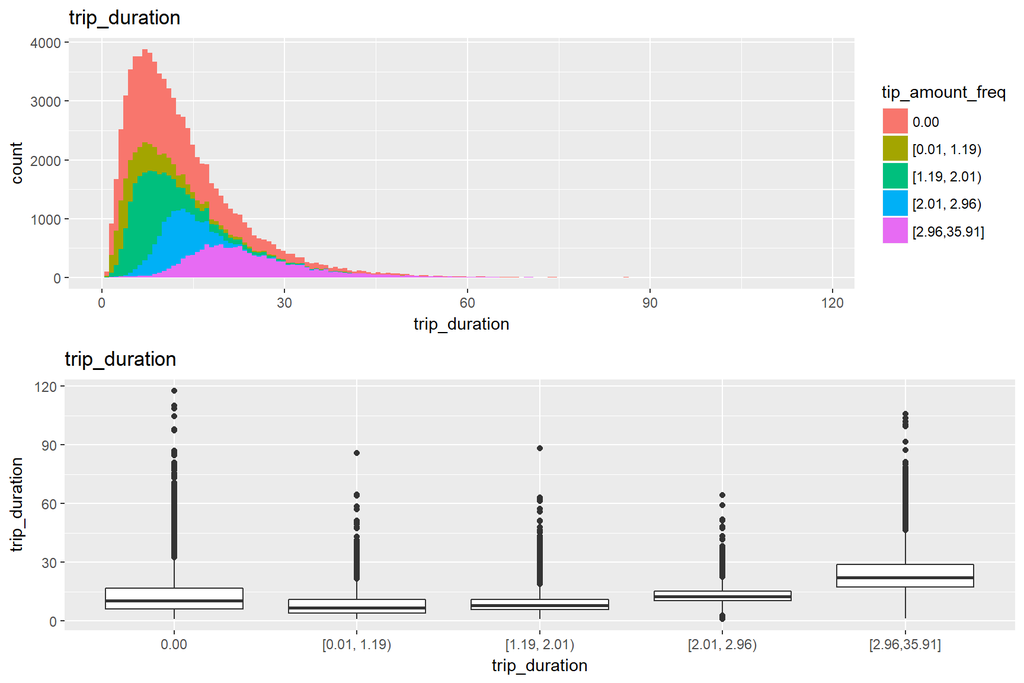

Fig. 3

```r
p1 <- train %>%
  ggplot(aes(x = trip_duration, fill = tip_amount_freq)) +
  geom_histogram(bins = 150) +
  labs(x = "trip_duration") +
  ggtitle("trip_duration")

p2 <- train %>%
  ggplot(aes(x = tip_amount_freq, y = trip_duration )) +
  geom_boxplot() +
  #theme(axis.text.x = element_text(angle = 90, hjust = 1)) +
  labs(x = "trip_duration") +
  ggtitle("trip_duration")

layout <- matrix(c(1,2),2,1,byrow=FALSE)
multiplot(p1, p2, layout=layout)
```

### 3.1.2 trip_distance

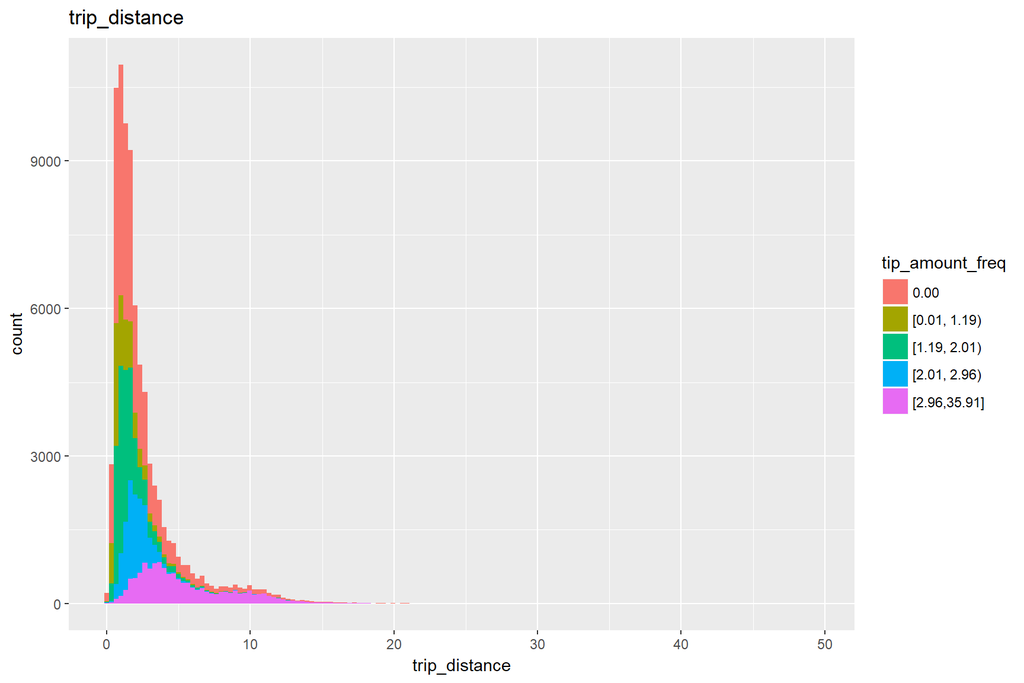

Fig. 3

```r
train %>%
  ggplot(aes(x = trip_distance, fill = tip_amount_freq)) +
  geom_histogram(bins = 150) +
  labs(x = "trip_distance") +
  ggtitle("trip_distance")
```

### 3.1.3 fare_amount

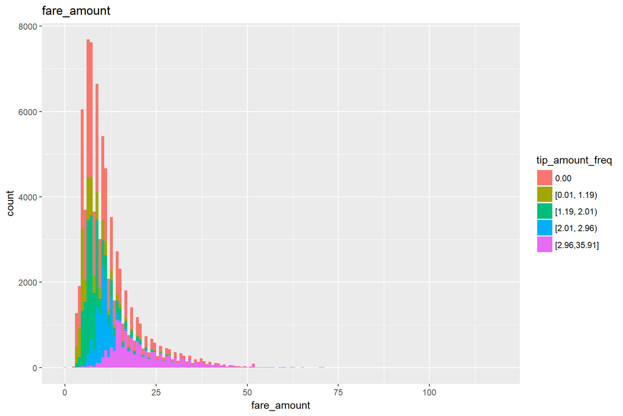

Fig. 3

```r
train %>%
  ggplot(aes(x = fare_amount, fill = tip_amount_freq)) +
  geom_histogram(bins = 150) +
  labs(x = "fare_amount") +
  ggtitle("fare_amount")
```

### 3.1.4 tolls_amount

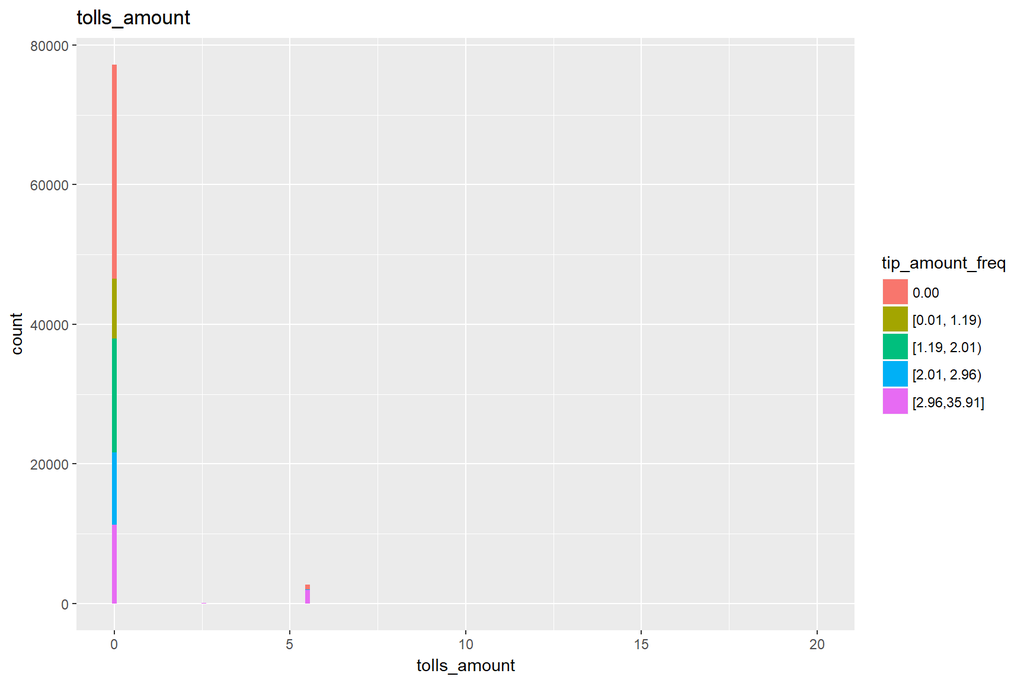

Fig. 3

```r
train %>%
  ggplot(aes(x = tolls_amount, fill = tip_amount_freq)) +
  geom_histogram(bins = 150) +
  labs(x = "tolls_amount") +
  ggtitle("tolls_amount")
```

## 3.2 Categorical Features

### 3.2.1 Pickup_borough

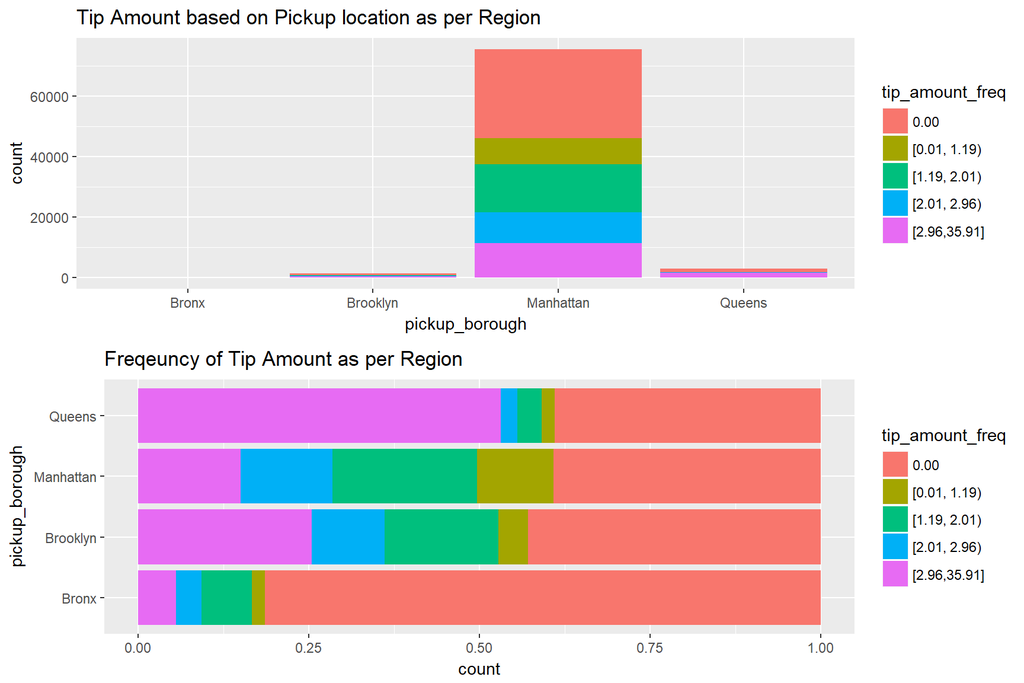

Fig. 3

```r
p1 <- train %>%
  ggplot(aes(x = pickup_borough, fill = tip_amount_freq)) +
  geom_bar() +
  labs(x = "pickup_borough") +
  ggtitle("Tip Amount based on Pickup location as per Region")


p2 <- train %>%
  ggplot(aes(x = pickup_borough, fill = tip_amount_freq)) +
  geom_bar(position = "fill") +
  coord_flip() +
  #theme(axis.text.x = element_text(angle = 90, hjust = 1)) +
  labs(x = "pickup_borough") +
  ggtitle("Freqeuncy of Tip Amount as per Region")

layout <- matrix(c(1,2),2,1,byrow=FALSE)
multiplot(p1, p2, layout=layout)
```

### 3.2.2 Tip Amount based on Pickup location as per Neighborhood

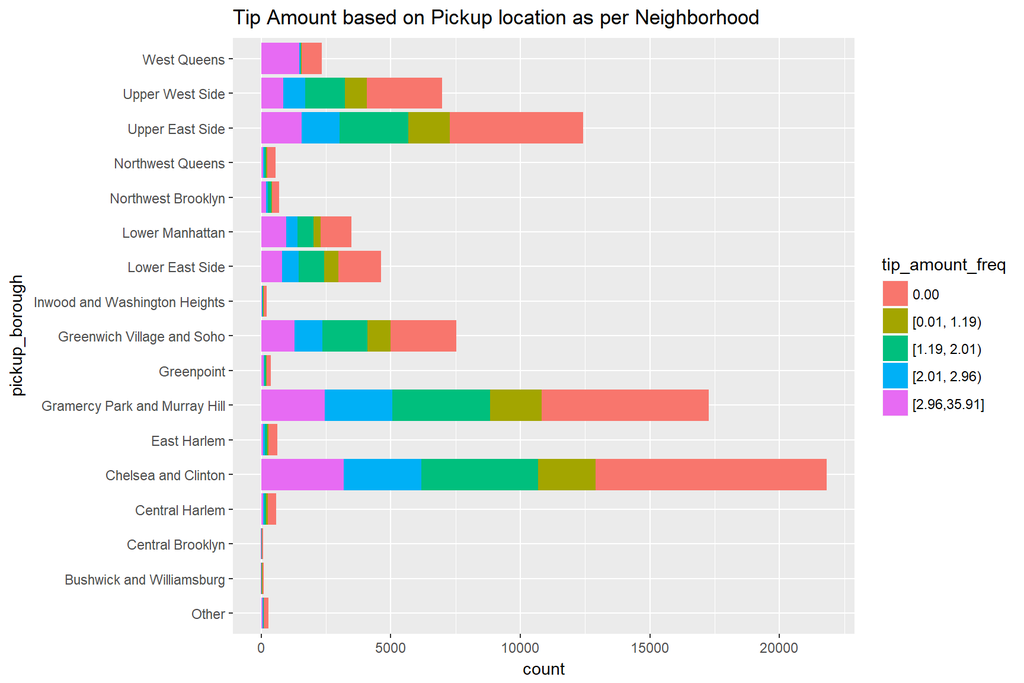

Fig. 3

```r
 train %>%
  ggplot(aes(x = pickup_neighborhood, fill = tip_amount_freq)) +
  geom_bar() +
  coord_flip() +
  labs(x = "pickup_borough") +
  ggtitle("Tip Amount based on Pickup location as per Neighborhood")
```

### 3.2.3 Freqeuncy of Tip Amount as per Neighborhood

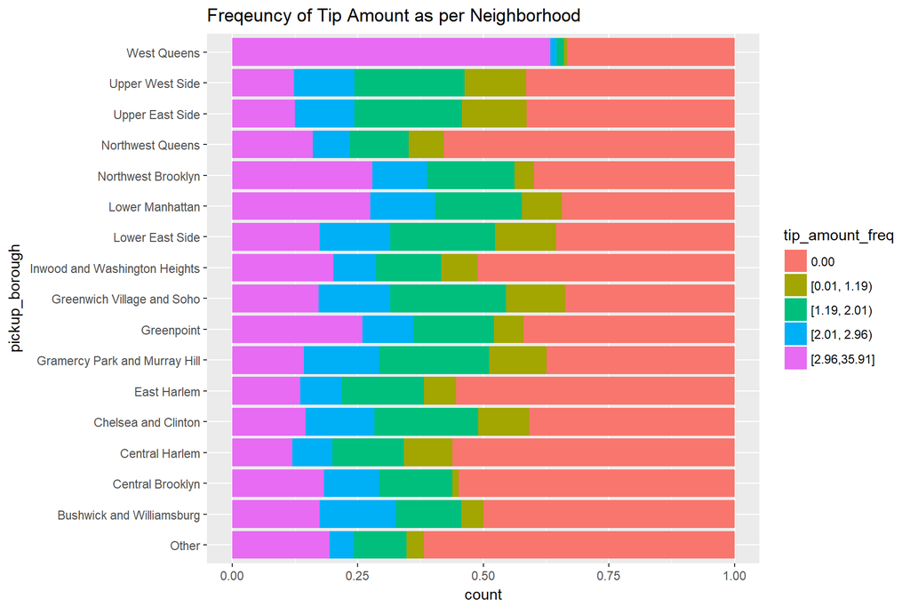

Fig. 3

```r
 train %>%
  ggplot(aes(x = pickup_neighborhood, fill = tip_amount_freq)) +
  geom_bar(position = "fill") +
  coord_flip() +
  labs(x = "pickup_borough") +
  ggtitle("Freqeuncy of Tip Amount as per Neighborhood")
```

### 3.2.4 dropoff location

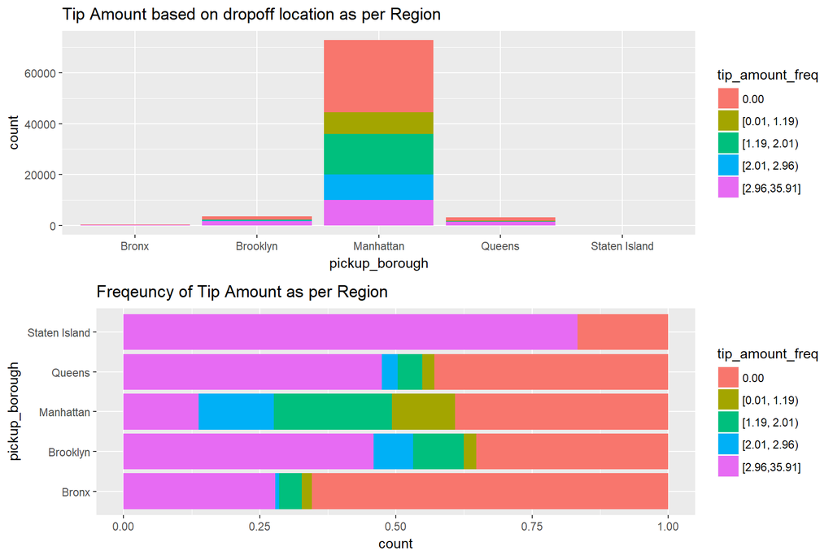

Fig. 3

```r
p1 <- train %>%
  ggplot(aes(x = dropoff_borough, fill = tip_amount_freq)) +
  geom_bar() +
  labs(x = "pickup_borough") +
  ggtitle("Tip Amount based on dropoff location as per Region")

p2 <- train %>%
  ggplot(aes(x = dropoff_borough, fill = tip_amount_freq)) +
  geom_bar(position = "fill") +
  coord_flip() +
  labs(x = "pickup_borough") +
  ggtitle("Freqeuncy of Tip Amount as per Region")

layout <- matrix(c(1,2),2,1,byrow=FALSE)
multiplot(p1, p2, layout=layout)
```

### 3.2.5 Tip Amount based on dropoff location as per Neighborhood

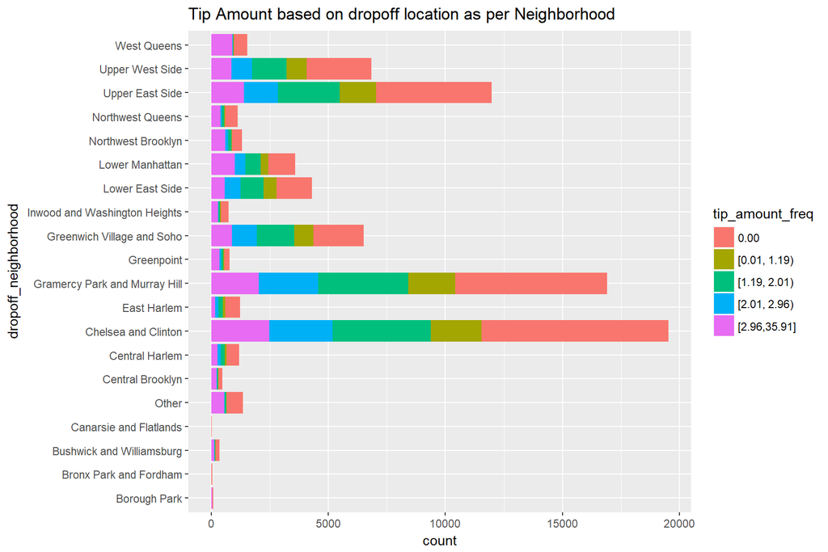

Fig. 3

```r
 train %>%
  ggplot(aes(x = dropoff_neighborhood, fill = tip_amount_freq)) +
  geom_bar() +
  coord_flip() +
  labs(x = "dropoff_neighborhood") +
  ggtitle("Tip Amount based on dropoff location as per Neighborhood")
```

### 3.2.6 Freqeuncy of Tip Amount as per Neighborhood

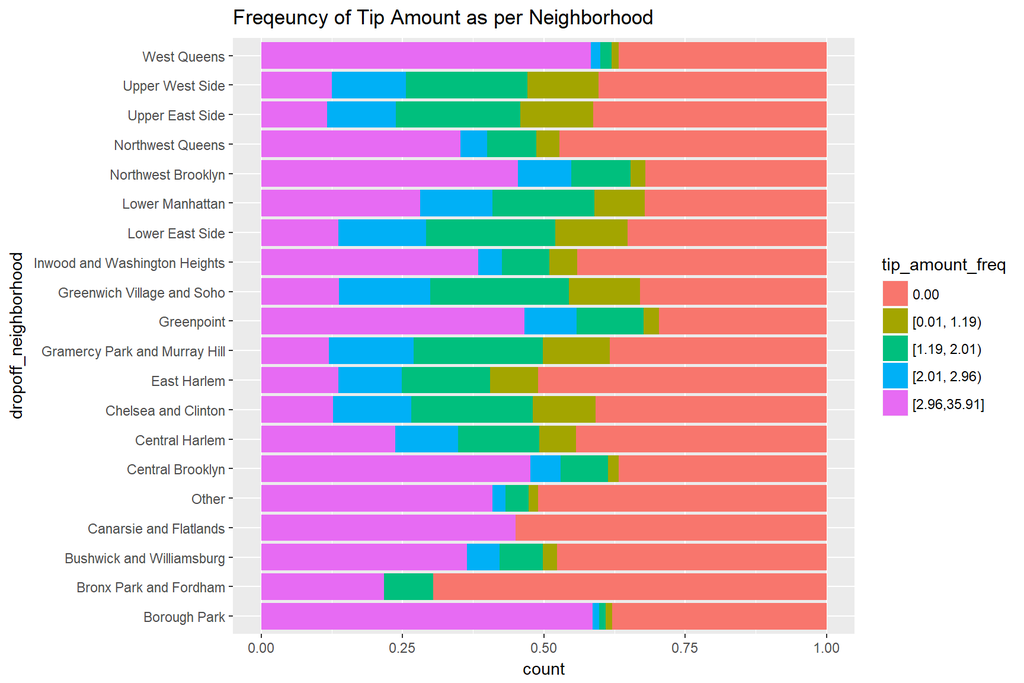

Fig. 3

```r
train %>%
  ggplot(aes(x = dropoff_neighborhood, fill = tip_amount_freq)) +
  geom_bar(position = "fill") +
  coord_flip() +
  labs(x = "dropoff_neighborhood") +
  ggtitle("Freqeuncy of Tip Amount as per Neighborhood")
```

### 3.2.7 Payment Type and Passanger Count

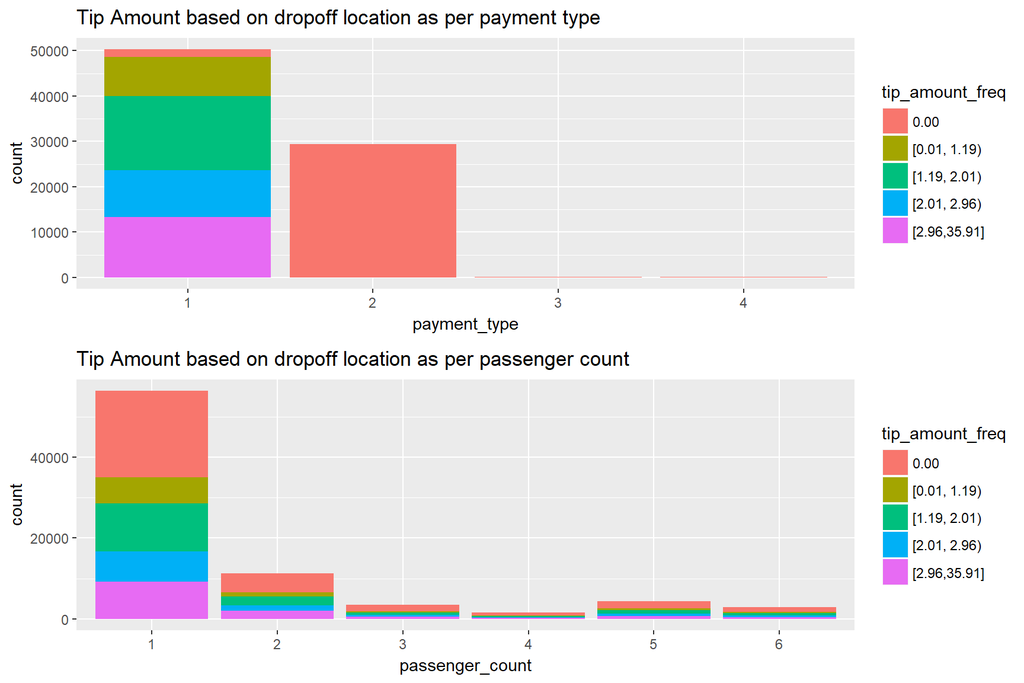

Fig. 3

```r
p1 <- train %>%
  ggplot(aes(x = payment_type, fill = tip_amount_freq)) +
  geom_bar() +
  labs(x = "payment_type") +
  ggtitle("Tip Amount based on dropoff location as per payment type")

p2 <- train %>%
  ggplot(aes(x = passenger_count, fill = tip_amount_freq)) +
  geom_bar() +
  labs(x = "passenger_count") +
  ggtitle("Tip Amount based on dropoff location as per passenger count ")

layout <- matrix(c(1,2),2,1,byrow=FALSE)
multiplot(p1, p2, layout=layout)
```

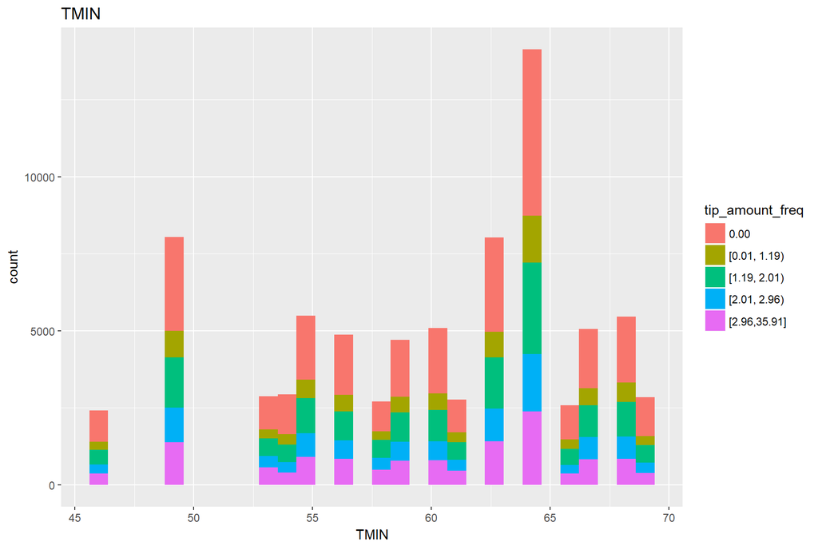

Fig. 3

```r
train %>%
  ggplot(aes(x = TMIN, fill = tip_amount_freq)) +
  geom_histogram(bins = 30) +
  labs(x = "TMIN") +
  ggtitle("TMIN")
```

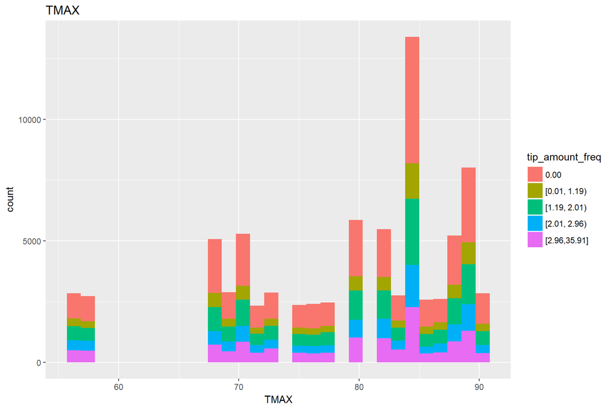

Fig. 3

```r
train %>%
  ggplot(aes(x = TMAX, fill = tip_amount_freq)) +
  geom_histogram(bins = 30) +
  labs(x = "TMAX") +
  ggtitle("TMAX")
```

## 3.3 Time Features

### 3.3.1 pickup_datetime per Month and Day

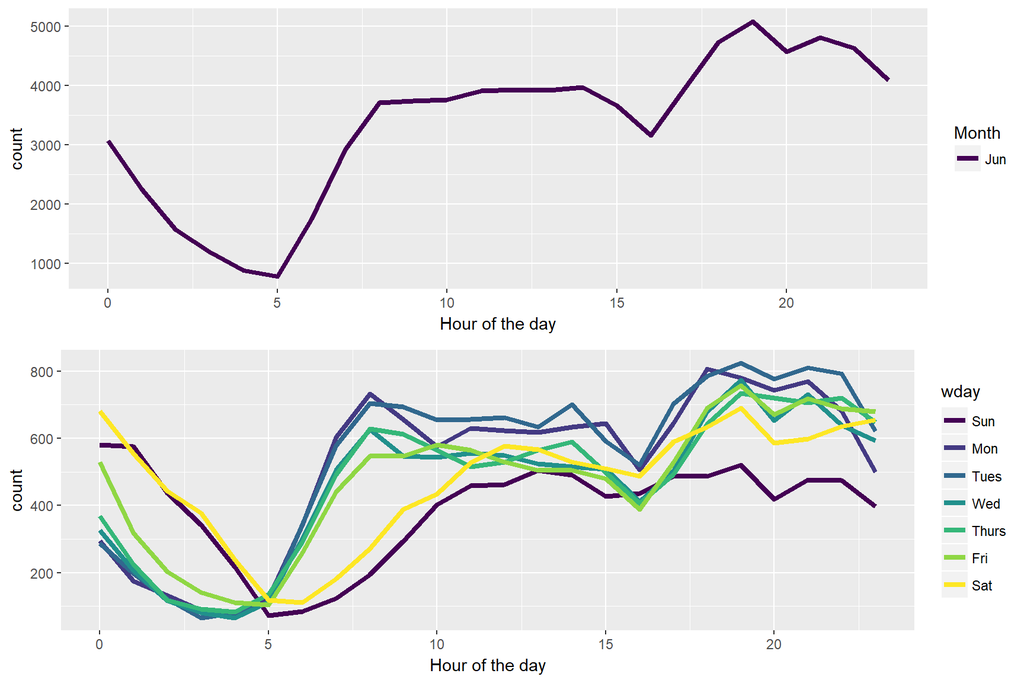

Fig. 3

```r
p1 <- train %>%
  mutate(hpick = hour(pickup_datetime),
         Month = factor(month(pickup_datetime, label = TRUE))) %>%
  group_by(hpick, Month) %>%
  count() %>%
  ggplot(aes(hpick, n, color = Month)) +
  geom_line(size = 1.5) +
  labs(x = "Hour of the day", y = "count")

p2 <- train %>%
  mutate(hpick = hour(pickup_datetime),
         wday = factor(wday(pickup_datetime, label = TRUE))) %>%
  group_by(hpick, wday) %>%
  count() %>%
  ggplot(aes(hpick, n, color = wday)) +
  geom_line(size = 1.5) +
  labs(x = "Hour of the day", y = "count")

layout <- matrix(c(1,2),2,1,byrow=FALSE)
multiplot(p1, p2, layout=layout)
```

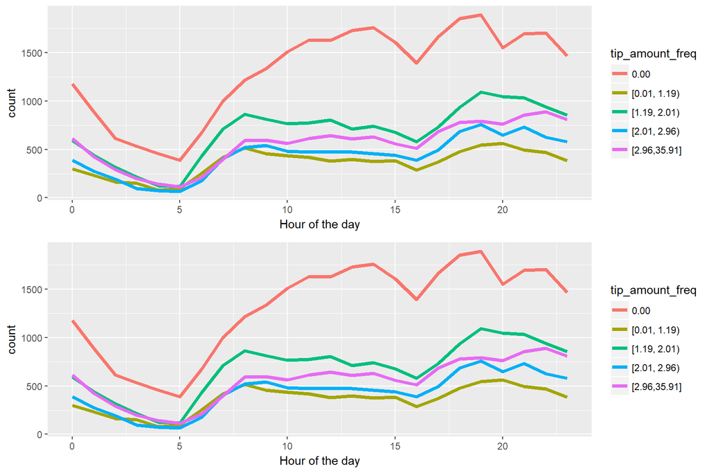

Fig. 3

```r
p1 <- train %>%
  mutate(hpick = hour(pickup_datetime),
         Month = factor(month(pickup_datetime, label = TRUE))) %>%
  group_by(hpick, tip_amount_freq) %>%
  count() %>%
  ggplot(aes(hpick, n, color = tip_amount_freq)) +
  geom_line(size = 1.5) +
  labs(x = "Hour of the day", y = "count")

p2 <- train %>%
  mutate(hpick = hour(pickup_datetime),
         wday = factor(wday(pickup_datetime, label = TRUE))) %>%
  group_by(hpick, tip_amount_freq) %>%
  count() %>%
  ggplot(aes(hpick, n, color = tip_amount_freq)) +
  geom_line(size = 1.5) +
  labs(x = "Hour of the day", y = "count")

layout <- matrix(c(1,2),2,1,byrow=FALSE)
multiplot(p1, p2, layout=layout)
```

### 3.3.2 Drop Off per Month and Day

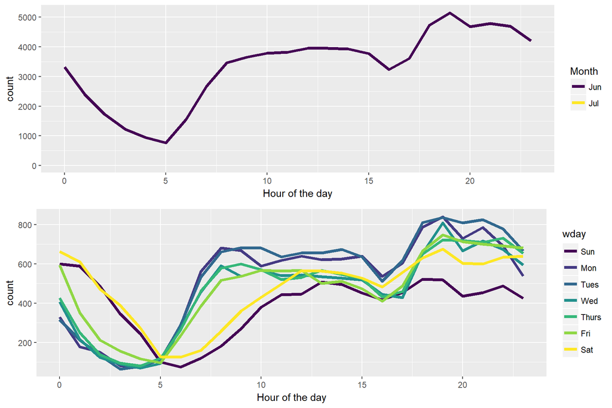

Fig. 3

```r
p1 <- train %>%
  mutate(hpick = hour(dropoff_datetime),
         Month = factor(month(dropoff_datetime, label = TRUE))) %>%
  group_by(hpick, Month) %>%
  count() %>%
  ggplot(aes(hpick, n, color = Month)) +
  geom_line(size = 1.5) +
  labs(x = "Hour of the day", y = "count")

p2 <- train %>%
  mutate(hpick = hour(dropoff_datetime),
         wday = factor(wday(dropoff_datetime, label = TRUE))) %>%
  group_by(hpick, wday) %>%
  count() %>%
  ggplot(aes(hpick, n, color = wday)) +
  geom_line(size = 1.5) +
  labs(x = "Hour of the day", y = "count")

layout <- matrix(c(1,2),2,1,byrow=FALSE)
multiplot(p1, p2, layout=layout)
```

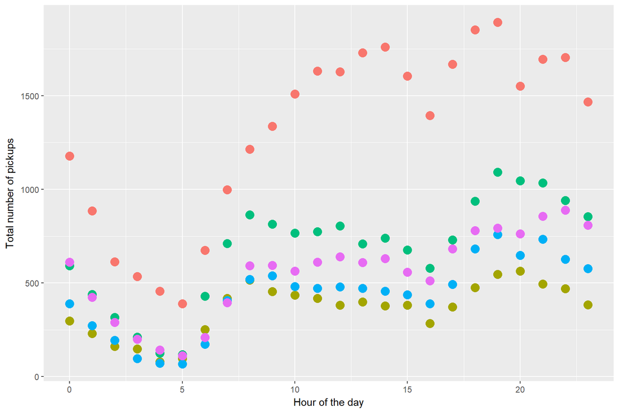

Fig. 3

```r
train %>%
  mutate(hpick = hour(pickup_datetime)) %>%
  group_by(hpick, tip_amount_freq) %>%
  count() %>%
  ggplot(aes(hpick, n, color = tip_amount_freq)) +
  geom_point(size = 4) +
  labs(x = "Hour of the day", y = "Total number of pickups") +
  theme(legend.position = "none")
```

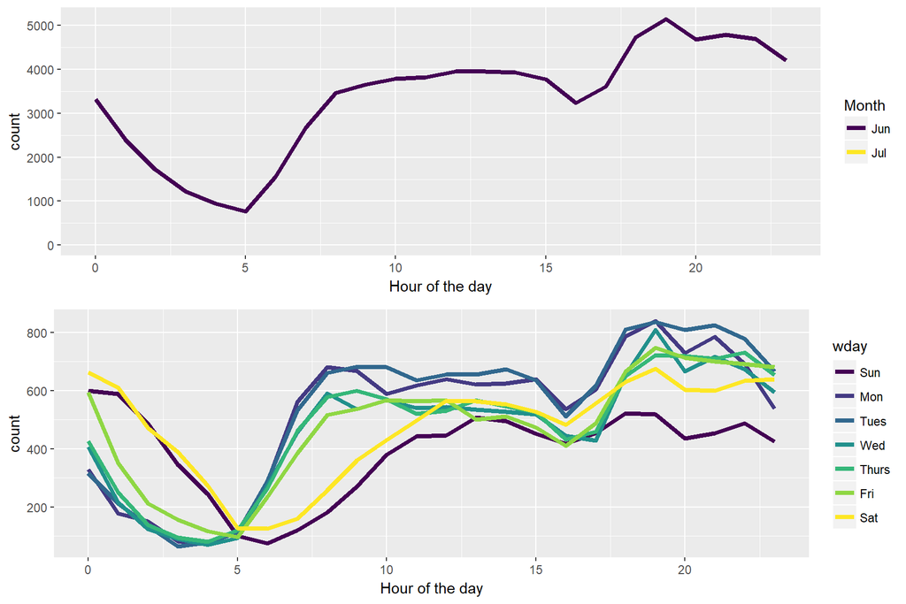

Fig. 3

```r
p1 <- train %>%
  mutate(hpick = hour(dropoff_datetime),
         Month = factor(month(dropoff_datetime, label = TRUE))) %>%
  group_by(hpick, Month) %>%
  count() %>%
  ggplot(aes(hpick, n, color = Month)) +
  geom_line(size = 1.5) +
  labs(x = "Hour of the day", y = "count")

p2 <- train %>%
  mutate(hpick = hour(dropoff_datetime),
         wday = factor(wday(dropoff_datetime, label = TRUE))) %>%
  group_by(hpick, wday) %>%
  count() %>%
  ggplot(aes(hpick, n, color = wday)) +
  geom_line(size = 1.5) +
  labs(x = "Hour of the day", y = "count")

layout <- matrix(c(1,2),2,1,byrow=FALSE)
multiplot(p1, p2, layout=layout)
```

## 3.4 Target Feature

### 3.4.1 Target Feature

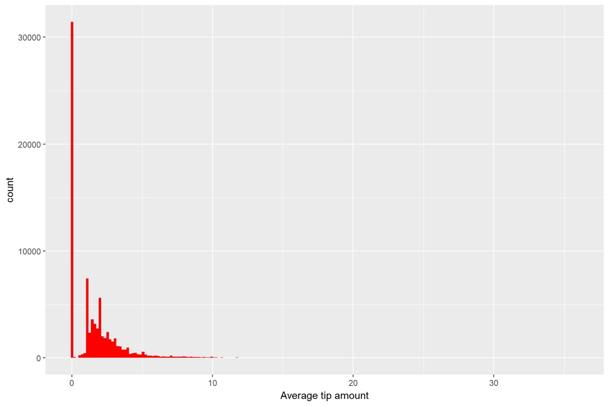

Fig. 3

```r
train %>%
  ggplot(aes(x = tip_amount)) +
  geom_histogram(fill = "red", bins = 200) +
  labs(x = "Average tip amount")
```

### 3.4.2 Target Feature with scale_y_log10

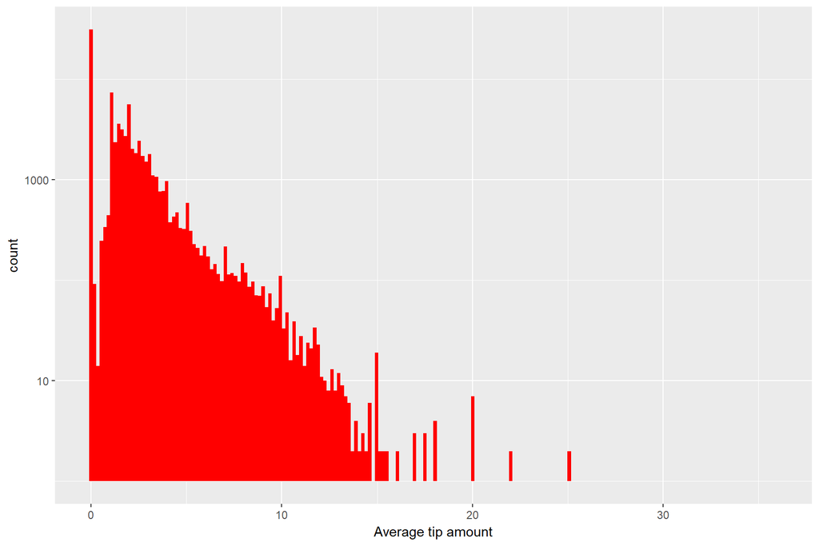

Fig. 3

```r
train %>%
  ggplot(aes(x = tip_amount)) +
  geom_histogram(fill = "red", bins = 200) +
  scale_y_log10() +
  labs(x = "Average tip amount")
```

### 3.4.3 Target Feature with scale_y_log10 and filter tip_amount > 0.1

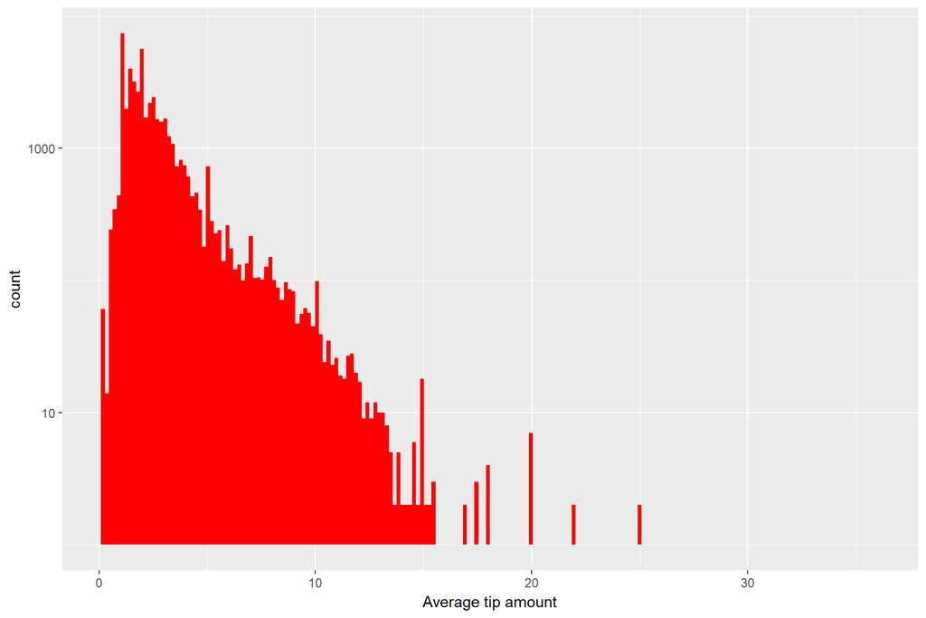

Fig. 3

```r
train %>%
  filter(tip_amount > 0.1) %>%
  ggplot(aes(x = tip_amount)) +
  geom_histogram(fill = "red", bins = 200) +
  scale_y_log10() +
  labs(x = "Average tip amount")
```

## 3.5 Correlation

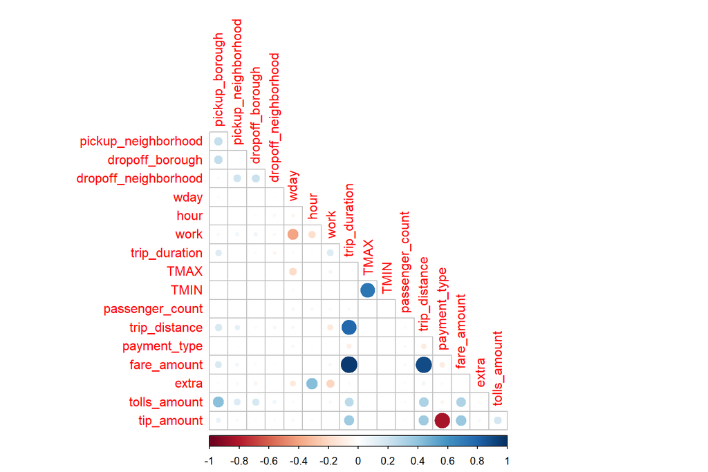

Fig. 3

```r
correlation <- train %>%
  select(pickup_borough, pickup_neighborhood, dropoff_borough,dropoff_neighborhood,
         wday, hour, work, trip_duration, TMAX, TMIN,
         passenger_count, trip_distance, payment_type, fare_amount,
         extra, tolls_amount, tip_amount) %>%
  mutate(TMIN = as.integer(TMIN),
         TMAX = as.integer(TMAX),
         trip_duration = as.integer(trip_duration),
         work = as.integer(work),
         hour = as.integer(hour),
         wday = as.integer(wday),
         dropoff_neighborhood = as.integer(dropoff_neighborhood),
         dropoff_borough = as.integer(dropoff_borough),
         pickup_neighborhood = as.integer(pickup_neighborhood),
         pickup_borough = as.integer(pickup_borough),
         passenger_count = as.integer(passenger_count),
         trip_distance = as.integer(trip_distance),
         payment_type = as.integer(payment_type),
         fare_amount = as.integer(fare_amount),
         extra = as.integer(extra),
         tolls_amount = as.integer(tolls_amount),
         tip_amount = as.integer(tip_amount))

correlation %>%
  cor(use="complete.obs", method = "spearman") %>%
  corrplot(type="lower", method="circle", diag=FALSE)
```